# Project Report

### Team Members:

Project Coordinator: Ashley Anderson

Team Members: Cameron Stocker, Hexiang Zhang, & Tyler Kruzan

### Dataset Overview

The dataset can be found on Kaggle or through this link:  
https://www.kaggle.com/PromptCloudHQ/imdb-data

### Background

Our choice of a data set came from IMDb and includes data about the 1,000 most popular movies that came out between 2006 and 2016. Useful variables include Title, Director, Year, Runtime, Rating, Metascore, & Revenue. Below is a table of all variables in the dataset as well as a description for each. There are some messy variables such as Description, Actors, & Genre that contain lengthy character strings that will be parsed and cleaned or simply omitted from the final data we use.

IMDb, which stands for Internet Movie Database, is an online source for data associated with films, TV shows, video games, and other streamable content. For each title, users can find information relating to the starring cast, producers, and plot summaries, as well as both critic and fan reviews. As of May 2019, IMDb had 83 million registered users and approximately 6 million titles, including 516,726 feature films. IMDb ratings are based on user ratings on a scale from 1 to 10. The raw ratings are then filtered and weighted, creating a weighted mean rating for each film. The formula for calculating the weighted rating is $W = \frac{R*v + C*m}{v+m}$, where $R$ is the raw average, $v$ is the number of votes, $m$ is the minimum votes required to be included in the Top 250 (which is currently 25,000), and $C$ is the mean vote for the reports (which is currently 7.0).

| Dataset Variables | Description |
| --- | --- |
| Rank | Movie Rank Order |
| Title | Tite of the film |
| Genre | Comma separated-list of genres used to classify the film |
| Description | Brief one-sentence movie summary |
| Director | The name of the film’s director |
| Actors | A comma-separated list of the main stars of the film |
| Year | The year that the film released as an integer. |
| Runtime (Minutes) | The duration of the film in minutes. |
| Rating | Average user rating for the movie on a 0-10 scale |
| Votes | Total number of ratings given per movie |
| Revenue (Millions) | Movie revenue in millions |
| Metascore | An aggregated average of critic scores. Values are between 0 and 100. Higher scores represent positive reviews. |

### Pipeline

We begin by describing our plan of attack for the project. Beginning with the raw data set, we start with some exploration in order to see what looked messy or unusual in order to determine what needs to be fixed or removed. We then move on to wrangling and cleaning the data based on what we found during the exploration.

For analysis, we will examine a variety of questions. First we will find which actors and directors are most commonly involved with successful movies. We define success by looking at a movie’s rating, revenue, or metascore. We will do this by finding the average movie rating and revenue on an actor and director specific basis.

We will also dive into what factors are correlated with a high rating and revenue. Specifically, we look at how runtime effects these success variables and if it has any significance in predicting rating or revenue. This can be done through ploting the dataset.

We also examine relationships between different factors in a movie over time, such as looking at the relationship between the year a film was made with the performance of the film, using variables like runtime, votes, rating, and revenue. We will do this to see how the components of top movies have changed over the years.

Lastly, we explore how different genres perform in term of success; including ratings, revenue, and metascore. We also compare these success variables to each other to see which genre is most “successful” and which one is least “successful”.

### Data Exploration, Cleaning and Wrangling

From looking at the structure of the raw data set, we can see that each variable type seems to be correct, so no changes were needed there. However, we noticed that there were some other problems. First, we noticed a few NAs in the data set and decided to explore more. As we can see in the table below, there are quite a few NAs in the Revenue and Metascore column. Since these variables are both important for our definition of success, we decided to remove all rows that contained any NAs. It was also crucial to do so in some of our analyses that used averages, as we did not want NAs to effect our results.

|  | Count of NAs |
| --- | --- |
| Rank | 0 |
| Title | 0 |
| Genre | 0 |
| Description | 0 |
| Director | 0 |
| Actors | 0 |
| Year | 0 |
| Runtime..Minutes. | 0 |
| Rating | 0 |
| Votes | 0 |
| Revenue..Millions. | 128 |
| Metascore | 64 |

Second, some of the variables in the data set are messy or need renamed. We decided to drop the Rank and Description columns because these variables are lengthy and difficult to use. Additionally, we do not believe they would add much value to our analysis. Next, we changed the variable names for Runtime and Revenue so that they did not include their units (minutes and millions) in the name, making them easier to use later.

Next, the genre variable shows multiple genres for each movie seperated by a comma. In order for this variable to be useful, we need to separate them. We do this by separating the genres and then spreading the column out so each unique genre is it’s own column. The movies recognized under a certain genre display a “1” value, and those that are not display a “0” value.

Lastly, the Actor variable shows the most important four actors for each movie separated by a comma. Again, for this column to be useful, we will need to isolate each actor for each movie. We do this by separating the “Actors” column into four different columns: Actor1, Actor2, Actor3, and Actor4.

### Data Analysis

#### Which actors and directors are most/least successful?

##### Actor Analysis

For our actor analysis, we used both the Revenue and Metascore variables to examine ‘success’.

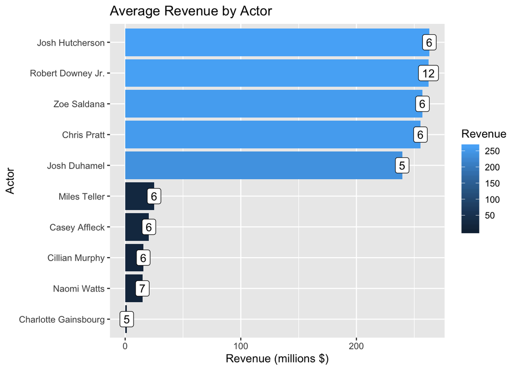

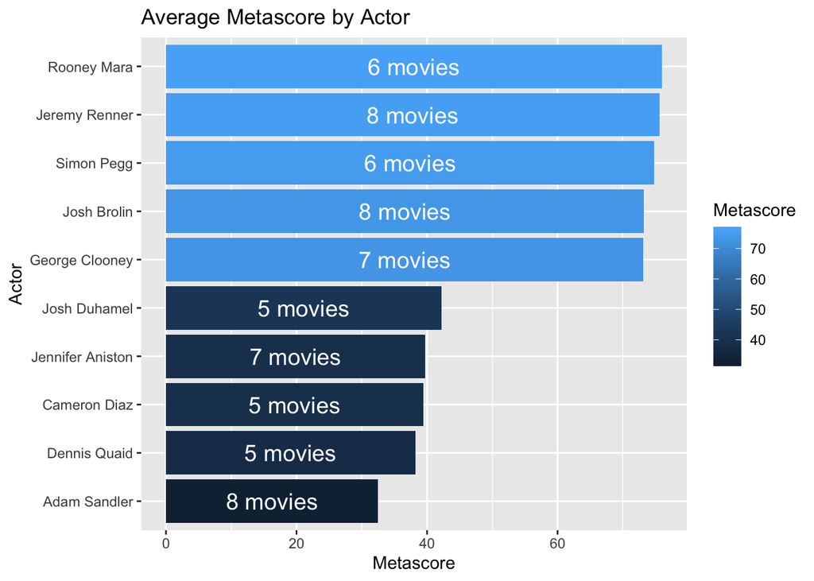

As we can see from the plot above, Rooney Mara had the highest average metascore while Adam Sandler had the lowest. Although Adam Sandler is widely considered to be successful, he has been involved in some comedy movies that had very low ratings and this plot highlights that.

##### Director Analysis

For the director analysis, we used the Rating statistic to define ‘success’. As we can see from the plot below, the top 3 directors for average movie rating were Christopher Nolan, Quentin Tarantino, and Martin Scorsese. This is interesting because if you ask people who they think are some of the top directors in the world, you would likely hear these names come up. This plot confirms that belief that these three directors are some of the most successful.

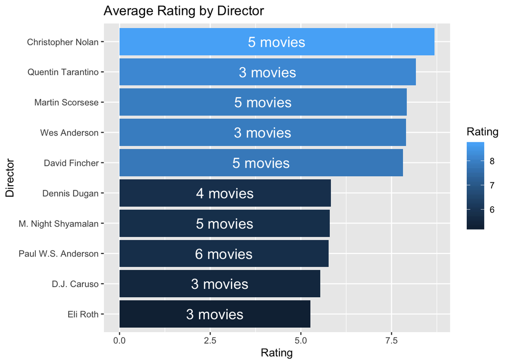

#### How is runtime correlated with high ratings and revenue?

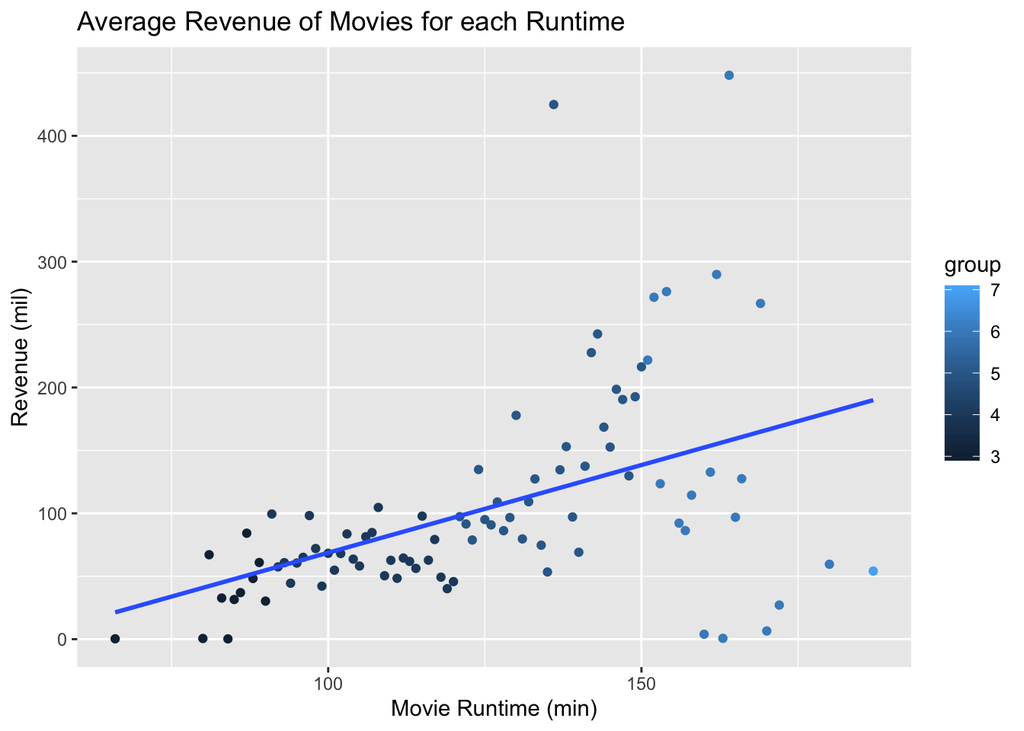

In the plot above, we wanted to analyze how the runtime of a movie was related to the amount of revenue it made. As we can see, it appears that the averagae revenue has a positive correlation with the runtime of a movie. To further analyze this correlation, we decided to run a linear regression model to see if this relationship is signficant and if we could use runtime to predict a film’s revenue.

```
##
## Call:
## lm(formula = mean_rev ~ Runtime, data = movie2)
##
## Residuals:
##      Min       1Q   Median       3Q      Max
## -159.736  -30.182   -9.573   19.504  306.003
##
## Coefficients:
##             Estimate Std. Error t value Pr(>|t|)
## (Intercept) -70.7046    36.0329  -1.962   0.0529 .
## Runtime       1.3939     0.2816   4.950 3.54e-06 ***
## ---
## Signif. codes:  0 '***' 0.001 '**' 0.01 '*' 0.05 '.' 0.1 ' ' 1
##
## Residual standard error: 73.33 on 88 degrees of freedom
## Multiple R-squared:  0.2178, Adjusted R-squared:  0.2089
## F-statistic: 24.51 on 1 and 88 DF,  p-value: 3.541e-06
```

As we can see from the output above, the p-value for the linear regression model is $3.541*10^{-6}$, which is less than any reasonale alpha value. This means the model is significant. Additionally, the p-value for the predictor Runtime coefficient is $3.54*10^{-6}$, which is also significant. This says that in this linear regression model, runtime is a significant predictor of average revenue. On the other hand though, our adjusted $R^2$ value is $0.2089$. This means only about $20\%$ of the variability in the average revenue can be explained by this model while accounting for the number of terms in the model. Overall, due to the nature of p-values, we do not believe runtime is a good predictor of average revenue.

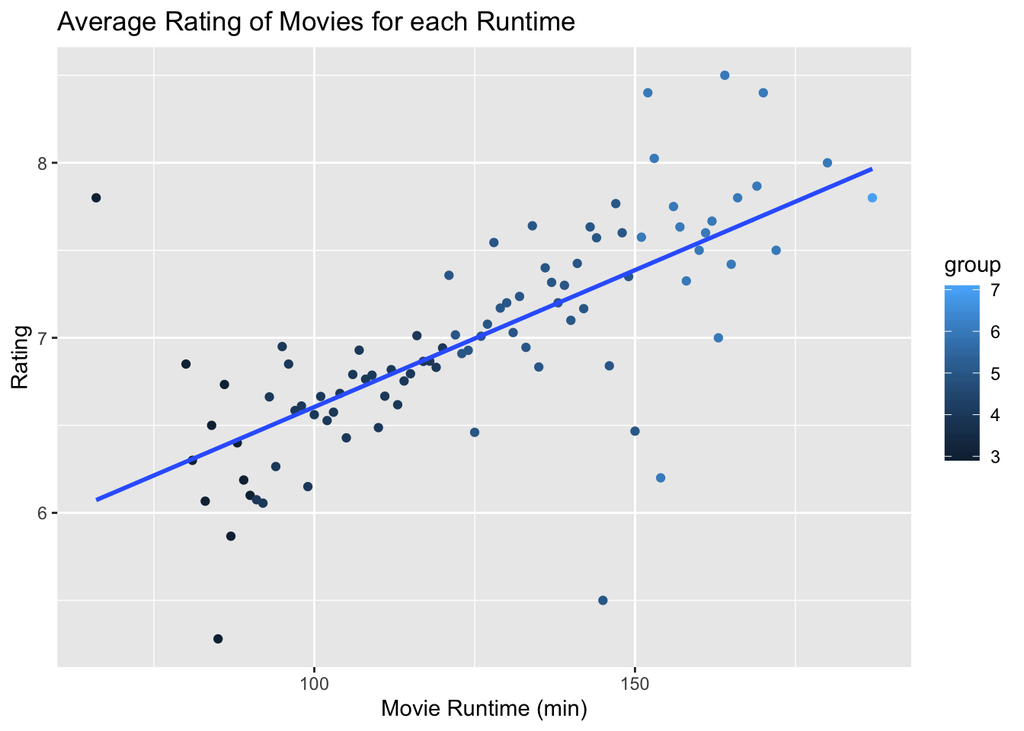

Now, we wanted to analyze how the runtime of a movie effects it’s rating. In the plot above, there appears to be a postive corrolation between rating and runtime of a film. People seem to rate longer movies more highly. However, there may be other factors that contribute the this corrolation. To analyze this observation, we again decided to run a linear regression model to see if this relationship is signficant and if we could use runtime to predict a film’s rating.

```
##
## Call:
## lm(formula = mean_rat ~ Runtime, data = movie2)
##
## Residuals:
##      Min       1Q   Median       3Q      Max
## -1.80865 -0.17302  0.01974  0.16612  1.72702
##
## Coefficients:
##             Estimate Std. Error t value Pr(>|t|)
## (Intercept) 5.040653   0.218149  23.107  < 2e-16 ***
## Runtime     0.015641   0.001705   9.175 1.79e-14 ***
## ---
## Signif. codes:  0 '***' 0.001 '**' 0.01 '*' 0.05 '.' 0.1 ' ' 1
##
## Residual standard error: 0.444 on 88 degrees of freedom
## Multiple R-squared:  0.4889, Adjusted R-squared:  0.4831
## F-statistic: 84.19 on 1 and 88 DF,  p-value: 1.787e-14
```

As we can see from the output above, the p-value for this linear regression model is $1.787*10^{-14}$, which is less than any reasonale alpha value. This means the model is significant. Additionally, the p-value for the predictor Runtime coefficient is $1.79*10^{-14}$, which is also significant. This says that in this linear regression model, runtime is a significant predictor of average rating. Additionally, our adjusted $R^2$ value is $0.4831$. This means about $48\%$ of the variability in the average rating can be explained by this model while accounting for the number of terms in the model. Overall, we believe runtime could be a good predictor of average rating.

#### How do the number of movies created change over time?

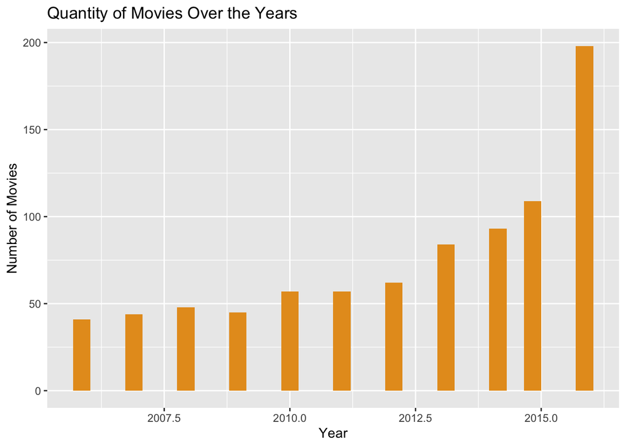

#### How do movie ratings compare over time?

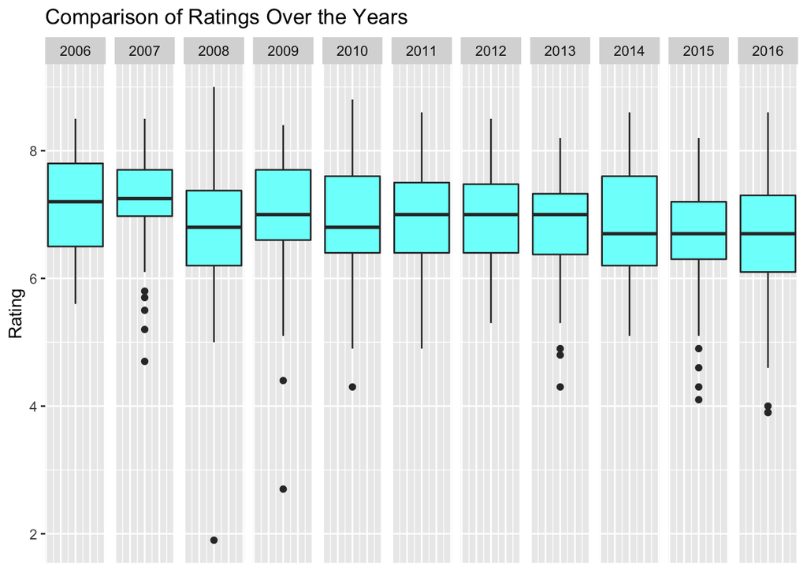

#### How have movie revenues changed over the years?

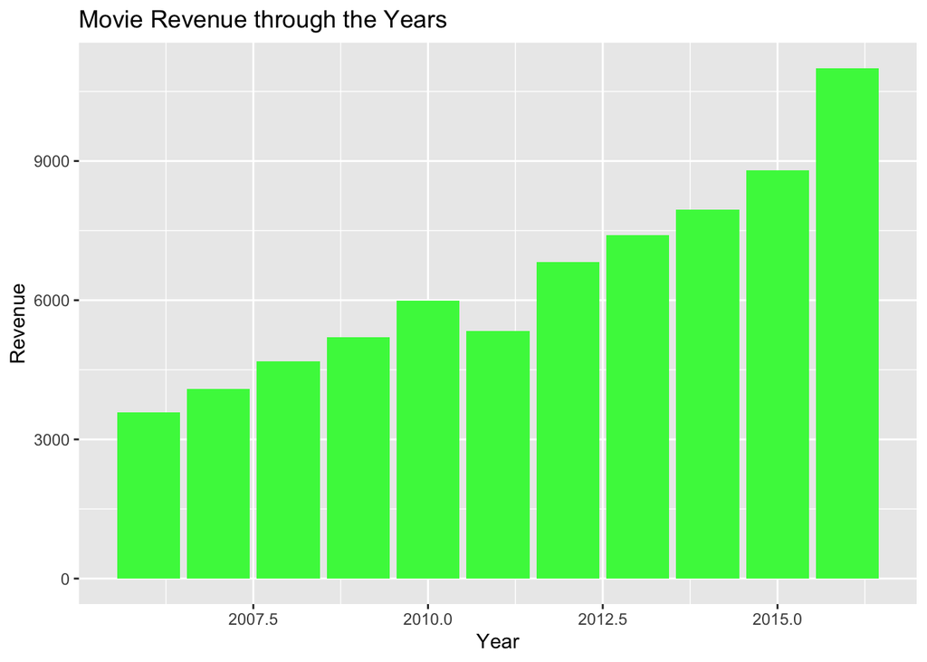

In the three graphs above you can see that the more movies released recently are included in the IMDb Top 1000 movies. Ratings have remained consistent over the years leading us to beleive that the rating variable is not biased to a specific year of movie production. Lastly, you can see that recent movies in the Top 1000 have made more money than those of previous years.

#### What genres are most successful?

In the graph below, there are three bar plots that represent the average revenue in millions by genre, the average metascore by genre, and the average rating by genre. This was done by creating a new data frame, which includes variables genre, average revenue, average rating, and average metascore. Each unique genre was represented once in the genre column, and for each unique genre, the averages for revenue, ratings, and metascore could be calculated using a for loop.

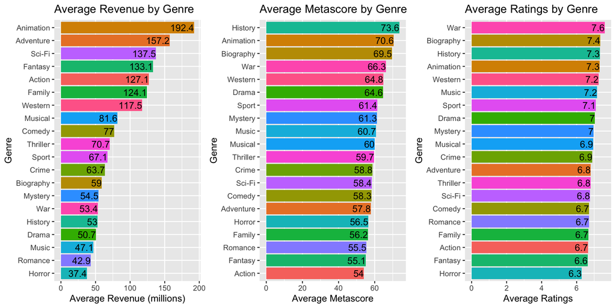

Comparing the three barplots, it is obvious that the genre ‘Animation’ performed very well. It had the top revenue of any revenue, exceeding the second highest average revenue genre by about $35 million for a total average of $192.4 million. Not only did ‘Animation’ films do well in producing revenue, we can see that they were second in average metascores with an average score of 70.6 out of 100, and fourth in average ratings with a rating of 7.3 out of 10. This means ‘Animation’ films were generally enjoyed by both critics and IMDb fans.

Conversely, the ‘Horror’ genre did not perform as well. Comparing the barplots, we see that ‘Horror’ movies accumulated the smallest amount of revenue out of any genre, which was about $37.4 million. Additionally, it performed among the bottom five average metascores, with an average score of 56.5 out of 100. Lastly, ‘Horror’ movies have the least favorable rating by IMDb fans, with an average rating of 6.3 out of 10. Overall, ‘Horror’ movies generally perform unsuccessfully.

There are some interesting trends to point out in these graphs. Genres like ‘Fantasy’, ‘Action’, and ‘Family’ recieved success in revenue, as they are among the top six genres for average revenue. However, we can see that these three genres were among the bottom four in both average metascore and average ratings. Thus, generally speaking, ‘Fantasy’, ‘Action’, and ‘Family’ movies generate a lot of revenue, but are not well recieved. This could be because these are genres a majority of the population watch, including children, meaning it can earn a large revenue. But just because a large proportion of the population watches a movie from this genre does not necessarily mean the movie will be well recieved.

Another trend to point out is opposite of the trend above genres. Genres like ‘History’, ‘War’ and ‘Biography’ do not seem to accumulate a ton of revenue. However, they are among the top four for average metascores and they are the top three genres for average ratings. Unlike ‘Fantasy’, ‘Action’, and ‘Family’, generally ‘History’, ‘War’ and ‘Biography’ movies are very well recieved, but do not generate a lot of money. This could be because these three genres a not generally as popular as a lot of people may find them boring and unexciting, meaning they do not generate as much revenue.

### Conclusion

One major take away from this project is that you cannot look at a single number when defining success. For one, when looking at which actors are most successful, there was no overlap in the top five actors who recieved the highest average revenue and the top five actors who recieved the highest average metascore. While some actors had success by making a lot of revenue from roles, others had success in their movies being well recieved by critics and fans. Similarly, when looking at which genres are most successful, there is sometimes a big difference in ranking between revenue, metascore, and ratings. For example, could see this in the fact that genres like ‘Fantasy’, ‘Action’, and ‘Family’ recieved high success in revenue but were among the bottom four in both average metascore and average ratings.

Through our analysis, we were able to discover why there are many ways to define the success of a movie. Going forward, it might be interesting to look into why certain actors, directors, and genres have higher success with revenue while others have higher success with critic and fan ratings. Additionally, it would be interesting to figure out why there is an increase in total number of movies being produced every year.

### Team Contribution

- Ashley: In this project, we decided to separate the data analysis section and we all focused on different questions of interest we came up together as a team. I specifically analyzed how genres of a movie contribute to it’s success, which was the last question analyzed above. I also organized our report document so we could be sure to follow the rubric and guidelines, as well as help to set up our presentation.
- Tyler: For this project, I did a lot of research for finding the dataset that we used. Additionally, I looked at the movie data over the time period that the dataset covered of 2006-2016, specifically the variables of revenue, rating, the number of movies produced each year. Lastly, I contributed to drafting our proposal, report, & presentation.
- Hexiang: I worked on cleaning some of the data. I worked on organizing the genre section of our project. I used separate and one hot encoded the movies and their genres. I worked on looking at how runtime is related to high revenue and high ratings from users on IMDb. I worked on create our powerpoint presenation presented in class.
- Cameron: I worked on cleaning some of the data. I separated the Actor variable into 4 different actor variables so that we could look at them individually. For analysis, I examined the which actors/directors were the most/least successful by using different variables. I believe the plots were very intuitive and effectively displayed the results we were looking for. I also was there to provide teammates with suggestions on how they could try to improve their analysis.